# $PM_{2.5}~Time~Series~Analysis$

# Our data

- We’re going to look at fine particle levels in Fort Collins during 2018

## Let’s take a look at our data

- It is vital you understand the contents of the data file(s) you are working with:
  - data format?
  - how are missing values represented?
  - naming conventions?
  - is my analysis software doing what I expect it to?

```r
head(data, 3)
```

```
## # A tibble: 3 x 6
##   date       time    pm_25 pm_10 pm_coarse datetime
##   <date>     <chr>   <dbl> <dbl>     <dbl> <dttm>
## 1 2018-01-01 1:00 AM    16    20       2.6 2018-01-01 01:00:00
## 2 2018-01-01 2:00 AM    17    22       2.9 2018-01-01 02:00:00
## 3 2018-01-01 3:00 AM    17    20       2   2018-01-01 03:00:00
```

## Graphically

- A plot is a quick way to get a handle on your data
  - what jumps outs?
  - did our data load as expected?
  - don’t go charging off with your complicated analysis too quickly!

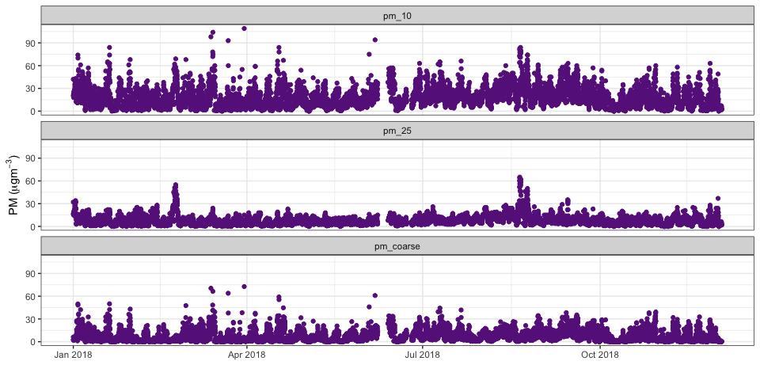

# Summarizing our data

- Your analysis software will have some tools for summarizing your data:

```r
summary(data[3:6])
```

```
##      pm_25           pm_10          pm_coarse
##  Min.   : 0.00   Min.   :  0.00   Min.   : 0.000
##  1st Qu.: 4.00   1st Qu.:  8.00   1st Qu.: 1.800
##  Median : 7.00   Median : 15.00   Median : 4.900
##  Mean   : 7.75   Mean   : 17.62   Mean   : 7.193
##  3rd Qu.:10.00   3rd Qu.: 24.00   3rd Qu.:10.500
##  Max.   :65.00   Max.   :109.00   Max.   :72.700
##     datetime
##  Min.   :2018-01-01 00:00:00
##  1st Qu.:2018-03-24 03:30:00
##  Median :2018-06-19 06:00:00
##  Mean   :2018-06-18 01:12:54
##  3rd Qu.:2018-09-12 02:30:00
##  Max.   :2018-12-02 23:00:00
```

- do the summary statistics make sense?
- what questions does this raise?

## Zeros

- Are they are large fraction of the dataset?
- Are they expected?
- How will they impact our planned analyses?

```
## # A tibble: 3 x 2
##   pollutant zeros
##   <chr>     <int>
## 1 pm_10       212
## 2 pm_25       212
## 3 pm_coarse   212
```

## Missing values

- Missing data can be particularly problematic for time series analysis:
  - how much of our data is missing?
  - why is it missing?
  - how should we deal with it?
- A general method to look for missing values is to create a vector of complete datetimes:

```r
head(datetimes, 5)
```

```
## # A tibble: 5 x 1
##   datetime
##   <dttm>
## 1 2018-01-01 00:00:00
## 2 2018-01-01 01:00:00
## 3 2018-01-01 02:00:00
## 4 2018-01-01 03:00:00
## 5 2018-01-01 04:00:00
```

- Then merge the dataset onto the complete vectors of datetimes, e.g.

```r
data_year <- left_join(datetimes, data, by = "datetime")
```

- We can then see how many observations are missing for the year by analyzing the merged object:

```
## # A tibble: 3 x 2
##   pollutant n_missing
##   <chr>         <int>
## 1 pm_10          2850
## 2 pm_25          2850
## 3 pm_coarse      2850
```

## Replacing values

- One approach is to replace the missing values with the previous non-missing value

```r
library(zoo)
data_replaced <- data_year %>%
                 na.locf()
```

If we do this the mean $PM_{2.5}$ value decreases from 7.8 to 7.5 $\mu g~m^{-3}$.

# Time series objects

- Tools for time series analyses

# Manipulating time series

- Smoothing
- Grouping
- Merging
- Lagging

# Plotting time series

- Best practices applied to time series
- Summary plots

# Trends

- Is there a trend in my data
- Autocorrelation
- Detrending
- Predictions
- Mean reversion

# Advanced time series analyses

- brief overview of other topics